Submitted By: Deepak Kumar Gupta (16200660)

# Load the oj.csv data into R.

```r
options(warn = 1)
oj <- read.csv(file="oj.csv",head=TRUE,sep=",")
summary(oj)
```

```
##      store                brand           week          logmove
##  Min.   :  2.00   dominicks  :9649   Min.   : 40.0   Min.   : 4.159
##  1st Qu.: 53.00   minute.maid:9649   1st Qu.: 70.0   1st Qu.: 8.490
##  Median : 86.00   tropicana  :9649   Median :101.0   Median : 9.034
##  Mean   : 80.88                      Mean   :100.5   Mean   : 9.168
##  3rd Qu.:111.00                      3rd Qu.:130.0   3rd Qu.: 9.765
##  Max.   :137.00                      Max.   :160.0   Max.   :13.482
##       feat            price           AGE60              EDUC
##  Min.   :0.0000   Min.   :0.520   Min.   :0.05805   Min.   :0.04955
##  1st Qu.:0.0000   1st Qu.:1.790   1st Qu.:0.12210   1st Qu.:0.14598
##  Median :0.0000   Median :2.170   Median :0.17065   Median :0.22939
##  Mean   :0.2373   Mean   :2.282   Mean   :0.17313   Mean   :0.22522
##  3rd Qu.:0.0000   3rd Qu.:2.730   3rd Qu.:0.21395   3rd Qu.:0.28439
##  Max.   :1.0000   Max.   :3.870   Max.   :0.30740   Max.   :0.52836
##      ETHNIC            INCOME          HHLARGE           WORKWOM
##  Min.   :0.02425   Min.   : 9.867   Min.   :0.01351   Min.   :0.2445
##  1st Qu.:0.04191   1st Qu.:10.456   1st Qu.:0.09794   1st Qu.:0.3126
##  Median :0.07466   Median :10.635   Median :0.11122   Median :0.3556
##  Mean   :0.15556   Mean   :10.617   Mean   :0.11560   Mean   :0.3592
##  3rd Qu.:0.18776   3rd Qu.:10.797   3rd Qu.:0.13517   3rd Qu.:0.4023
##  Max.   :0.99569   Max.   :11.236   Max.   :0.21635   Max.   :0.4723
##     HVAL150            SSTRDIST          SSTRVOL          CPDIST5
##  Min.   :0.002509   Min.   : 0.1321   Min.   :0.4000   Min.   :0.7725
##  1st Qu.:0.123486   1st Qu.: 2.7670   1st Qu.:0.7273   1st Qu.:1.6262
##  Median :0.346154   Median : 4.6507   Median :1.1154   Median :1.9634
##  Mean   :0.343766   Mean   : 5.0973   Mean   :1.2073   Mean   :2.1204
##  3rd Qu.:0.528313   3rd Qu.: 6.6506   3rd Qu.:1.5385   3rd Qu.:2.5337
##  Max.   :0.916700   Max.   :17.8560   Max.   :2.5714   Max.   :4.1079
##     CPWVOL5
##  Min.   :0.09456
##  1st Qu.:0.27167
##  Median :0.38323
##  Mean   :0.43891
##  3rd Qu.:0.56024
##  Max.   :1.14337
```

# How many records and how many attributes are in the orange juice dataset?

```r
dim(oj)
```

```
## [1] 28947    17
```

```r
names(oj)
```

```
##  [1] "store"    "brand"    "week"     "logmove"  "feat"     "price"
##  [7] "AGE60"    "EDUC"     "ETHNIC"   "INCOME"   "HHLARGE"  "WORKWOM"
## [13] "HVAL150"  "SSTRDIST" "SSTRVOL"  "CPDIST5"  "CPWVOL5"
```

# What is the mean, standard deviation and range of the price of orange juice?

```r
mean(oj$price)
```

```
## [1] 2.282488
```

```r
sd(oj$price)
```

```
## [1] 0.6480007
```

```r
range(oj$price)
```

```
## [1] 0.52 3.87
```

# What is the median of the ‘log of number of units sold’ (logmove)?

```r
median(oj$logmove)
```

```
## [1] 9.03408
```

# What are the names of the 3 orange juice brands?

```r
unique(oj$brand)
```

```
## [1] tropicana   minute.maid dominicks
## Levels: dominicks minute.maid tropicana
```

```r
juicebrand<- factor(oj$brand)
table(juicebrand)
```

```
## juicebrand
##   dominicks minute.maid   tropicana
##        9649        9649        9649
```

# Create a histogram of prices for each brand of orange juice.

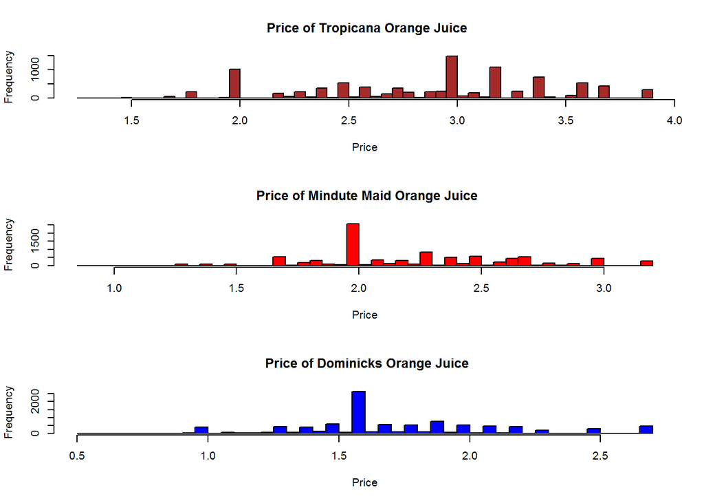

```r
library(lattice)
par(mfrow = c(3,1))
hist(oj$price[oj$brand=='tropicana'],main=" Price of Tropicana Orange Juice",xlab="Price",breaks =50, col = 'brown')
hist(oj$price[oj$brand=='minute.maid'],main=" Price of Mindute Maid Orange Juice",xlab="Price",breaks =50,col='Red')
hist(oj$price[oj$brand=='dominicks'],main=" Price of Dominicks Orange Juice",xlab="Price",breaks =50, col = 'blue')
```

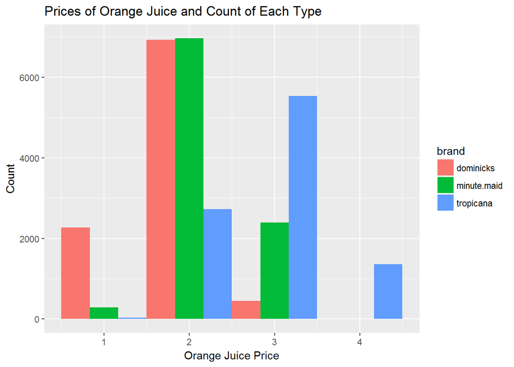

```r
#"Alternative Method Using ggplot2"
library(ggplot2)
ggplot(oj, aes(x= oj$price, fill = brand)) + geom_histogram(binwidth=1,position = "dodge")+ ylab("Count") +
  xlab("Orange Juice Price") +
  ggtitle("Prices of Orange Juice and Count of Each Type")
```

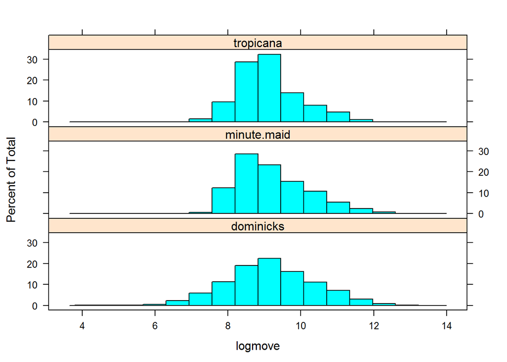

```r
histogram(~logmove|brand,data=oj,layout=c(1,3))
```

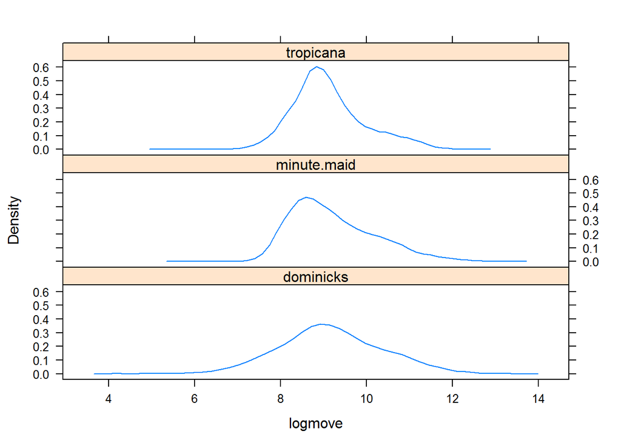

```r
densityplot(~logmove|brand,data=oj,layout=c(1,3),plot.points=FALSE)
```

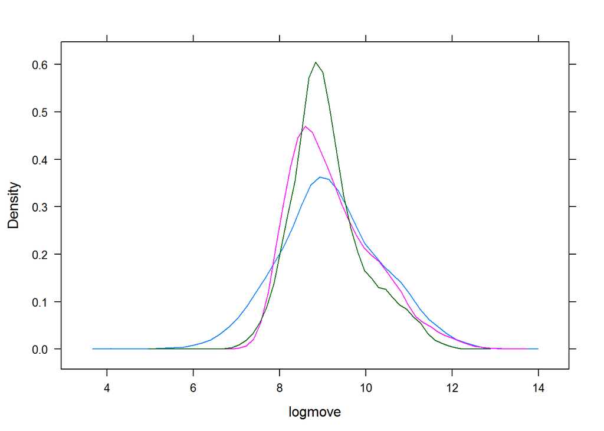

```r
densityplot(~logmove,groups=brand,data=oj,plot.points=FALSE)
```

# Generate a boxplot, which includes a separate plot for the prices of each brand.

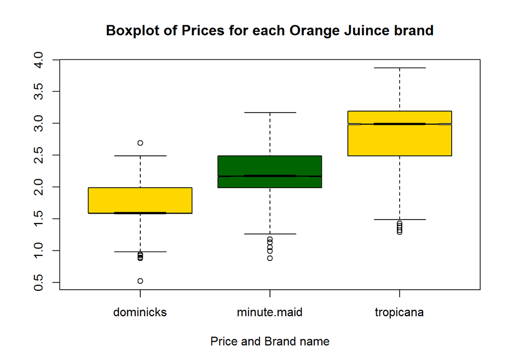

```r
boxplot(oj$price~oj$brand, data=oj, notch=TRUE,
  col=(c("gold","darkgreen")),main="Boxplot of Prices for each Orange Juince brand", xlab="Price and Brand name")
```

#What does the boxplot tell us about the relative prices of each brand?

# Generate a scatterplot of the logmove compared to price, and color

the points according to their brand (e.g., “red” for brand 1, “green” for brand 2 etc).

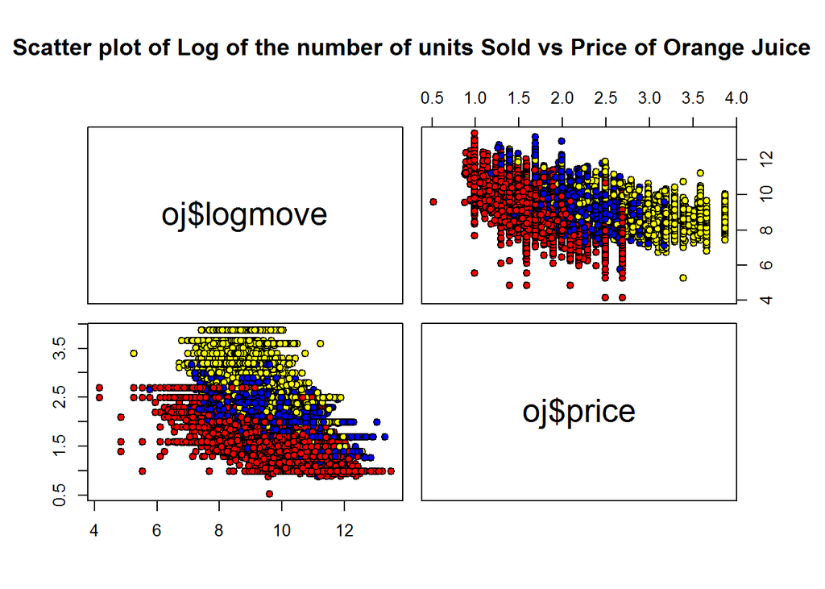

```r
library(scatterplot3d)
attach(oj)
pairs(~oj$logmove+oj$price, pch=21,main="Scatter plot of Log of the number of units Sold vs Price of Orange Juice",bg= c("red", "blue", "yellow")[unclass(oj$brand)])
```

[figure not shown]

```r
plot(oj$logmove,oj$price, xlab="Units Sold",ylab="Price",pch=21,col=topo.colors(3)[unclass(oj$brand)])
legend("bottomleft", inset=0.01, title="Brands",c("Tropicana","Minute Maid","Dominicks"), fill=topo.colors(3), horiz=FALSE)
```

```r
library(plotly)
Sys.setenv("plotly_username"="deepak91g")
Sys.setenv("plotly_api_key"="Gb3tMDu2UzMuGdXsMB9n")

p <- plot_ly(data = oj, x = ~logmove, y = ~price, color = ~brand, colors = "Set1")

# Create a shareable link to your chart
# Set up API credentials: https://plot.ly/r/getting-started
chart_link = plotly_POST(p, filename="colorbrewer")
```

```
## No encoding supplied: defaulting to UTF-8.
```

```
## Success! Modified your plotly here -> https://plot.ly/~deepak91g/1
```

```r
chart_link
```

[interactive chart not shown]

# Based on what you observe in the scatterplot, what can we say about the price of each brand of chilled orange juice and the volume of sales?

# Calculate the mean price of orange juice sold each week, and create a

line plot of this timeseries. (Hint: use tapply(), and an example plot is provided below.)

Note: Using tapply() method here

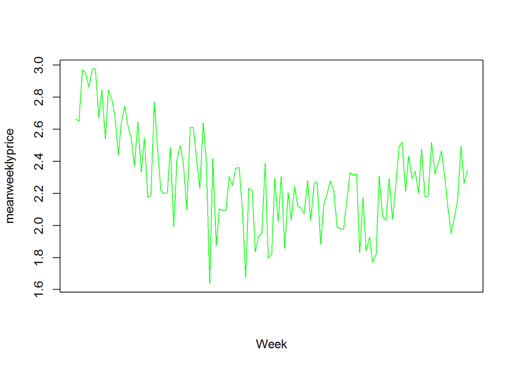

```r
xnames <- tapply(oj$price,oj$week,FUN=mean,na.rm=TRUE)
plot(tapply(oj$price,oj$week,FUN=mean,na.rm=TRUE),xaxt="n",pch=16,type="l",col="green",xlab = "Week",ylab="meanweeklyprice")
```

NOTE: Answer to question 11, using aggreagate method

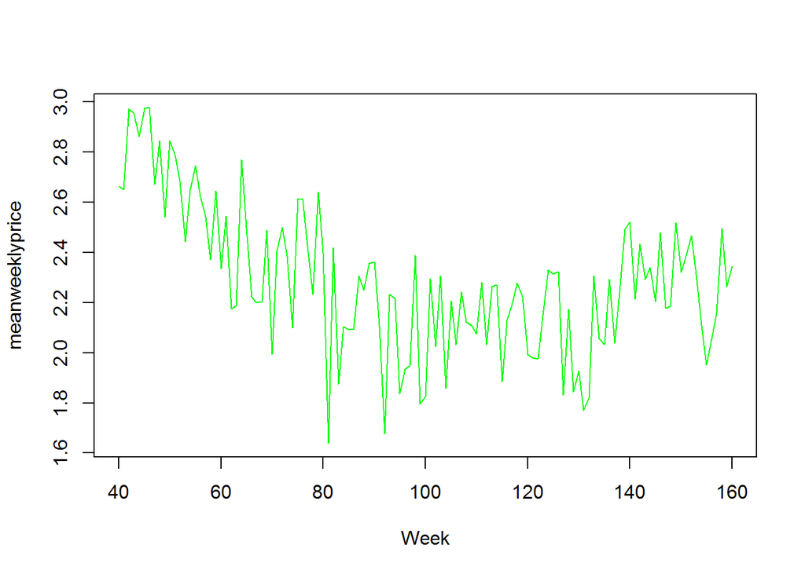

```r
meanweeklyprice <- aggregate(oj[ ,6], list(oj$week), mean)
plot(meanweeklyprice$Group.1,meanweeklyprice$x,type="l",col="green",xlab = "Week",ylab="meanweeklyprice")
```

# Extract the mean weekly price of orange juice sold each week according

to each brand (Hint: use tapply() with a list for the INDEX)

```r
#Solution :1 using aggregate()
mean_weekly_brand_price <- aggregate(oj[ ,6], list(Brand=oj$brand,Week=oj$week), mean)
head(mean_weekly_brand_price)
```

```
##         Brand Week        x
## 1   dominicks   40 1.590000
## 2 minute.maid   40 2.890000
## 3   tropicana   40 3.509315
## 4   dominicks   41 2.447015
## 5 minute.maid   41 1.990000
## 6   tropicana   41 3.514627
```

```r
#mean_weekly_brand_price  #Uncomment this to view full data frame

#Solution :2 using tapply()
weekly_brand_price<-tapply(oj$price,list(Week=oj$week,oj$brand),FUN=mean,na.rm=TRUE)
head(weekly_brand_price)
```

```
##
## Week dominicks minute.maid tropicana
##   40  1.590000    2.890000  3.509315
##   41  2.447015    1.990000  3.514627
##   42  2.461940    2.911343  3.536567
##   43  2.452597    2.892597  3.517792
##   44  2.463506    2.590000  3.534156
##   45  2.467838    2.908649  3.541486
```

```r
#weekly_brand_price  #Uncomment this to view full data frame
```

# Create a plot which compares the mean weekly price of orange juice

for all brands versus each individual brand.

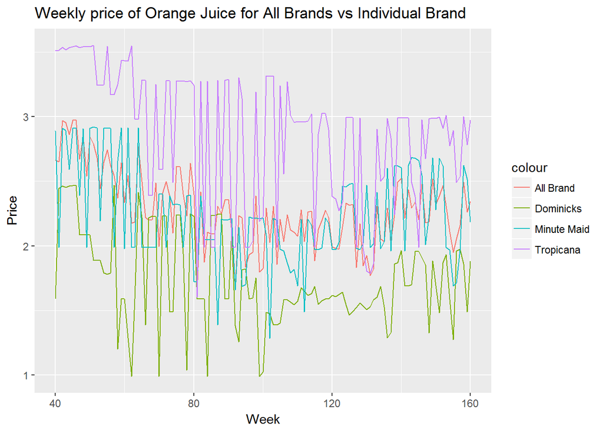

```r
weekly_brand_price<-tapply(oj$price,list(Week=oj$week,oj$brand),FUN=mean,na.rm=TRUE)
allbrand <- tapply(oj$price,list(Week=oj$week),FUN=mean,na.rm=TRUE)
df <- cbind(allbrand,weekly_brand_price)
write.table(df, file = 'q13.csv',sep = ",",row.names = T)
library(readr)
q13 <- read_csv("E:/Smurfit/Semester 2/DM/R/Data-Mining/q13.csv",
    col_names = FALSE, skip = 1)
ggplot(q13, aes(q13$X1),pch=21) +
  geom_line(aes(y = q13$X2, colour = "All Brand")) +
  geom_line(aes(y = q13$X3, colour = "Dominicks")) +
  geom_line(aes(y = q13$X4, colour = "Minute Maid")) +
  geom_line(aes(y = q13$X5, colour = "Tropicana")) + xlab("Week") +ylab("Price")+
  ggtitle("Weekly price of Orange Juice for All Brands vs Individual Brand")
```

# When there is an advertising campaign for orange juice does it impact on the number of units sold?

```r
adcap <- factor(oj$feat)
tapply(oj$logmove,adcap,FUN=mean,na.rm=TRUE)
```

```
##         0         1
##  8.862963 10.148049
```

# Can you create a line plot of the mean weekly units sold without a promotion overlayed with the mean weekly units sold with a promotion? What is interesting about this plot?

### Answer: With a promotion more number of units sold as compared to campaign without a promotion

```r
options(warn = -1)
unitsold<-tapply(oj$logmove,list(oj$week),FUN=mean,na.rm=TRUE)
head(unitsold)
```

```
##       40       41       42       43       44       45
## 8.598766 8.942384 8.298204 8.429358 8.741467 8.140365
```

[figure not shown]

```r
sold <- tapply(oj$logmove,list(Week=oj$week,oj$feat),FUN=mean,na.rm=TRUE)
df <- cbind(sold)
write.table(df, file = 'q15.csv',sep = ",",row.names = T)
library(readr)
q15 <- read_csv("E:/Smurfit/Semester 2/DM/R/Data-Mining/q15.csv",
    col_names = FALSE, skip = 1)
ggplot(q15, aes(q13$X1,xlab="Week")) +
  geom_line(aes(y = q13$X2, colour = "With promotion")) +
  geom_line(aes(y = q13$X3, colour = "Without promotion"))+ xlab("Week") +ylab("Units Sold")+
  ggtitle("Mean weekly units sold with a promotion vs without promotion")
```

#Descriptive Analytics Consider the demographic and competitive variables1. Using descriptive analytics are there patterns you can observe that might suggest the potential for profiling individual stores or customers, which might then be used for marketing purposes?

## Overview:

Actual data contains 28947 observations and 12 variables for demographic data.

```r
d1 <-(oj[c(1,7:17)])
dim(d1)
```

```
## [1] 28947    12
```

On analysing the data, it is found that, there were only 83 unique records out of 28947 obsservations. Therefore, data should be cleaned before performing any further descriptive analytics.

```r
d2 <- unique(oj[c(1,7:17)])
dim(d2)
```

```
## [1] 83 12
```

## Descriptive Analytics Summary for demographic data

This analysis will help one to understand the data, how it is distrbuted and how many observations are there etc.

```r
oj_subset <- unique(oj[c(1,7:17)])
oj_stats <- do.call(data.frame,
           list(Mean = apply(oj_subset, 2, mean),
                Std_Dev = apply(oj_subset, 2, sd),
                Median = apply(oj_subset, 2, median),
                Min = apply(oj_subset, 2, min),
                Max = apply(oj_subset, 2, max),
                N = apply(oj_subset, 2, length)))
oj_stats
```

```
##                Mean     Std_Dev      Median        Min         Max  N
## store    80.9277108 35.93448752 86.00000000 2.00000000 137.0000000 83
## AGE60     0.1729724  0.06221013  0.17065481 0.05805397   0.3073979 83
## EDUC      0.2257762  0.11114318  0.22939040 0.04955029   0.5283620 83
## ETHNIC    0.1546351  0.18782770  0.07465643 0.02424657   0.9956908 83
## INCOME   10.6176755  0.28344624 10.63532646 9.86708287  11.2361965 83
## HHLARGE   0.1156640  0.03035444  0.11122120 0.01350636   0.2163543 83
## WORKWOM   0.3591536  0.05280191  0.35563513 0.24446267   0.4723083 83
## HVAL150   0.3446528  0.24092599  0.34615385 0.00250941   0.9166995 83
## SSTRDIST  5.0969450  3.48872894  4.65068687 0.13209682  17.8559508 83
## SSTRVOL   1.2104260  0.53090387  1.11538461 0.40000000   2.5714286 83
## CPDIST5   2.1184928  0.73761928  1.96341236 0.77252973   4.1079018 83
## CPWVOL5   0.4393132  0.22067903  0.38322679 0.09456175   1.1433666 83
```

```r
cat("Statisical Summary of Orange Juice Data",fill=TRUE)
```

```
## Statisical Summary of Orange Juice Data
```

```r
stats_data =apply(as.matrix(oj_subset),2,quantile)
print(stats_data)
```

```
##      store      AGE60       EDUC     ETHNIC    INCOME    HHLARGE   WORKWOM
## 0%     2.0 0.05805397 0.04955029 0.02424657  9.867083 0.01350636 0.2444627
## 25%   53.5 0.12394915 0.14878867 0.04294112 10.468048 0.09804559 0.3129127
## 50%   86.0 0.17065481 0.22939040 0.07465643 10.635326 0.11122120 0.3556351
## 75%  110.5 0.21362903 0.28227241 0.17995974 10.795248 0.13345868 0.4021066
## 100% 137.0 0.30739786 0.52836201 0.99569076 11.236197 0.21635434 0.4723083
##         HVAL150   SSTRDIST   SSTRVOL   CPDIST5    CPWVOL5
## 0%   0.00250941  0.1320968 0.4000000 0.7725297 0.09456175
## 25%  0.12895177  2.8399843 0.7272727 1.6346475 0.28043820
## 50%  0.34615385  4.6506869 1.1153846 1.9634124 0.38322679
## 75%  0.51703001  6.5742868 1.5504808 2.5336557 0.55988695
## 100% 0.91669949 17.8559508 2.5714286 4.1079018 1.14336661
```

## Scatter Plot Matrices in R

### Analysis of Correlation among demographics variables.

#### 1. Positive Correlations:

```
    1. EDUC ~ CPWVOL5
    2. WORKWOM ~ CPWVOL5
    3. EDUC ~ WORKWOM
    4. EDUC ~ HVAL150
    5. WORKWOM ~ HVAL150
```

#### 1. Negative Correlations:

[output not shown]

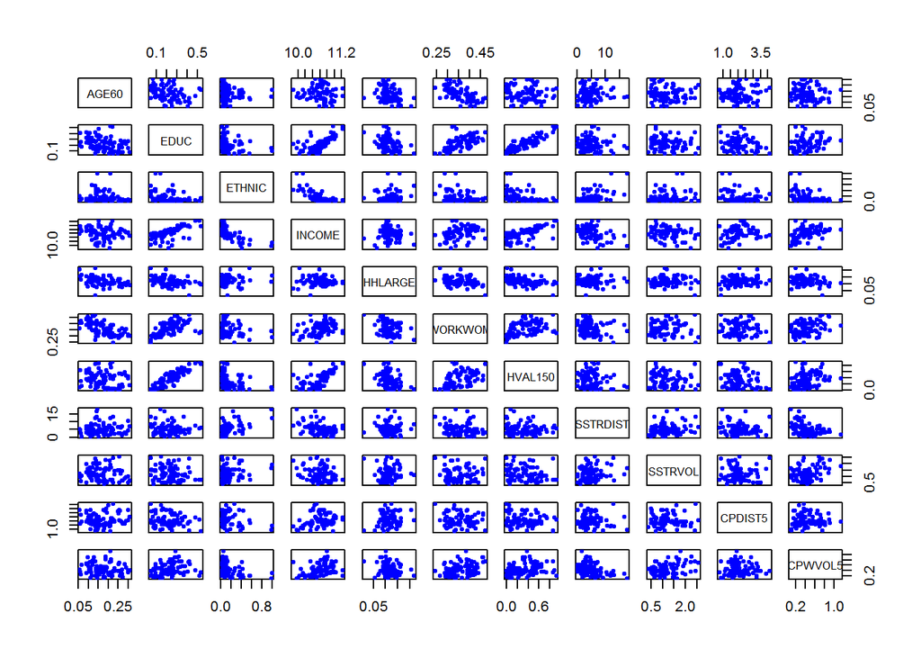

```r
#Scatter Plot to find correlation among demographics variables
pairs(oj_subset[,-1],col="blue",pch=20)
```

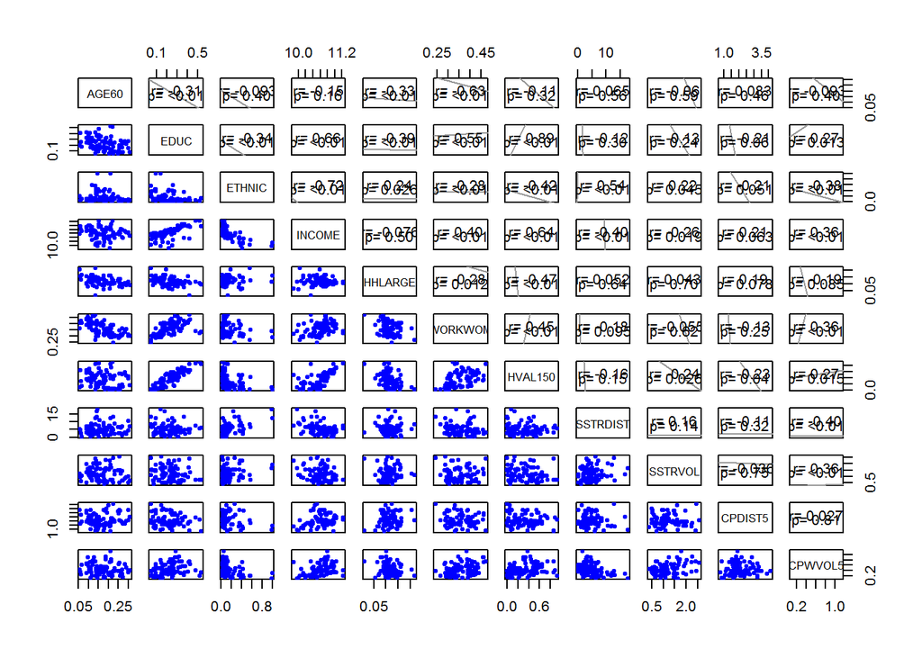

```r
#Reference: https://www.r-bloggers.com/scatter-plot-matrices-in-r/


#Scatter Plot with Correlation and P Value
panel.cor <- function(x, y, digits = 2, cex.cor=.8, ...)
{

  #Plotting Regression Line
  reg1 <- lm(x~y)
  abline(reg1,col = "gray60")

  usr <- par("usr"); on.exit(par(usr))
  par(usr = c(0, 1, 0, 1))
  # correlation coefficient
  r <- cor(x, y)
  txt <- format(c(r, 0.123456789), digits = digits)[1]
  txt <- paste("r= ", txt, sep = "")
  text(0.5, 0.6, txt)

  # p-value calculation
  p <- cor.test(x, y)$p.value
  txt2 <- format(c(p, 0.123456789), digits = digits)[1]
  txt2 <- paste("p= ", txt2, sep = "")
  if(p<0.01) txt2 <- paste("p= ", "<0.01", sep = "")
  text(0.5, 0.4, txt2)
}

pairs(oj_subset[,-1], upper.panel = panel.cor,col="blue",pch=20)
```

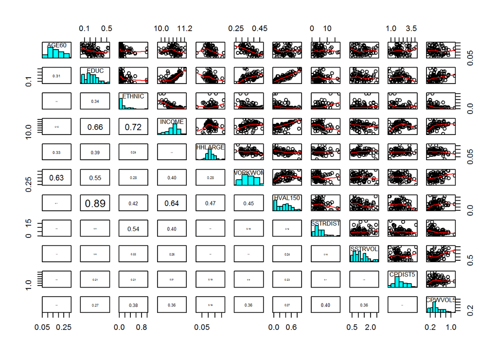

```r
library(s20x)
pairs20x(oj_subset[,-1])
```

## Boxplot and Histogram for Data Analysis

With the help of Boxplot, one is able to identify any outliers in the data, thereafter histogram plots help in checking the distribution of data, i.e whether data is normally distributed or not.

1. EDUC, ETHNNIC, INCOME, HHLARGE, SSTRDIST, CPDIST5 and CPWVOL5 has outliers

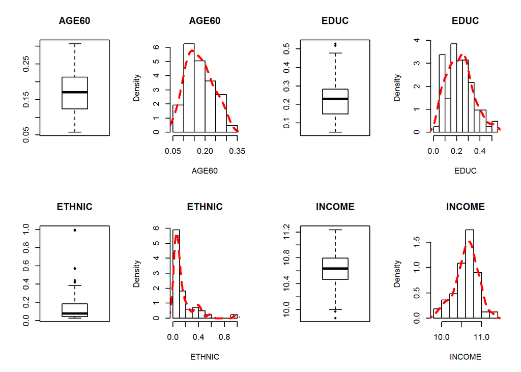

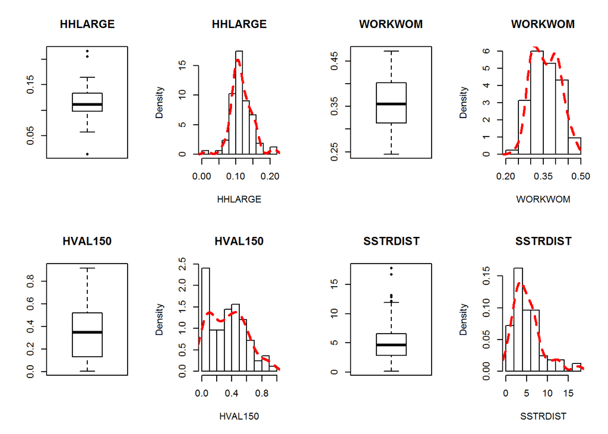

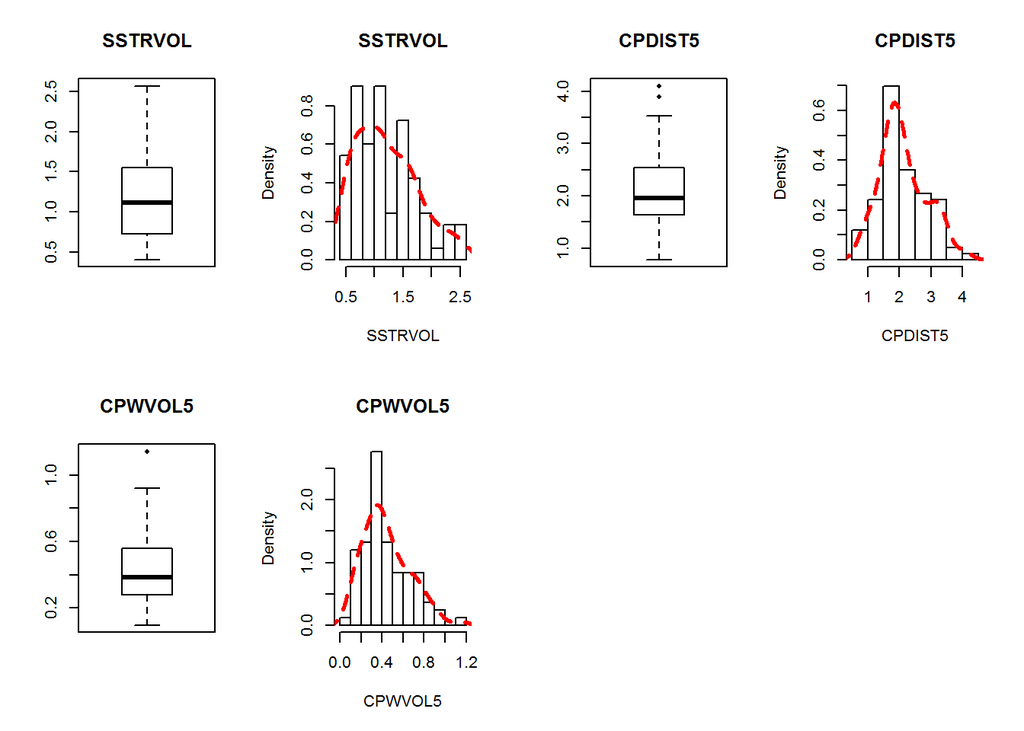

```r
par(mfrow = c(2, 4))
varlist <- names(oj_subset)[2:12]
box_hist_plot<-function(index) {
  boxplot(oj_subset[,index], main=names(oj_subset[index]),pch=16)
  hist(oj_subset[,index],main=names(oj_subset[index]),xlab=names(oj_subset[index]),prob=T)
  lines(density(oj_subset[,index]),lty="dashed",lwd=2.5,col="red")
  }
lapply(2:12,FUN=box_hist_plot)
```

### Weathliest Store and Poorest Store

```r
##Reference: Data Mining and Business Analytics with R Book by Johannes Ledolter
library(lattice)
t21=tapply(oj$INCOME,oj$store,FUN=mean,na.rm=TRUE)
t21
```

```
##         2         5         8         9        12        14        18
## 10.553205 10.922371 10.597010 10.787152  9.996659 11.043929 10.391976
##        21        28        32        33        40        44        45
## 10.716194 10.798534 10.674475 10.345927 10.550250 10.869159 10.745378
##        47        48        49        50        51        52        53
## 10.635326 10.756029 10.806754 10.589308 10.620839 11.051017 10.600004
##        54        56        59        62        64        67        68
## 10.910898 10.831825 10.715040 11.236197 10.605817 10.796960 10.188366
##        70        71        72        73        74        75        76
## 10.412351 10.404838 10.712193 10.614966 10.480017  9.867083 10.140613
##        77        78        80        81        83        84        86
## 10.983121 10.959175 10.909509 10.719936 10.456079 10.765618 10.088971
##        88        89        90        91        92        93        94
## 10.549805 10.308119 10.504656 10.538449 10.657800 10.367190 10.744516
##        95        97        98       100       101       102       103
## 10.383472 10.483746 10.573596 10.036575 10.659938 10.493854 10.585245
##       104       105       106       107       109       110       111
## 10.698853 10.414393 10.506847 10.827131 11.233198 10.520860 10.138283
##       112       113       114       115       116       117       118
## 10.882659 10.647660 10.347949 10.947485 10.697113 10.760962 10.632364
##       119       121       122       123       124       126       128
## 10.752719 10.949929 10.775053 10.334100 10.258957 10.980876 10.153429
##       129       130       131       132       134       137
## 10.999864  9.966650 10.793537 10.619154 10.722518 10.966490
```

```r
t21[t21==max(t21)]
```

```
##      62
## 11.2362
```

```r
t21[t21==min(t21)]
```

```
##       75
## 9.867083
```

```r
print(t21[t21==min(t21)])
```

```
##       75
## 9.867083
```

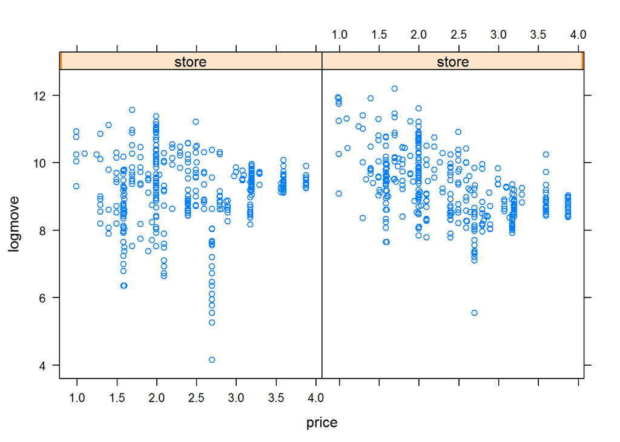

```r
oj1=oj[oj$store == 62,]
oj2=oj[oj$store == 75,]
oj3=rbind(oj1,oj2)
xyplot(logmove~price|store,data=oj3)
```

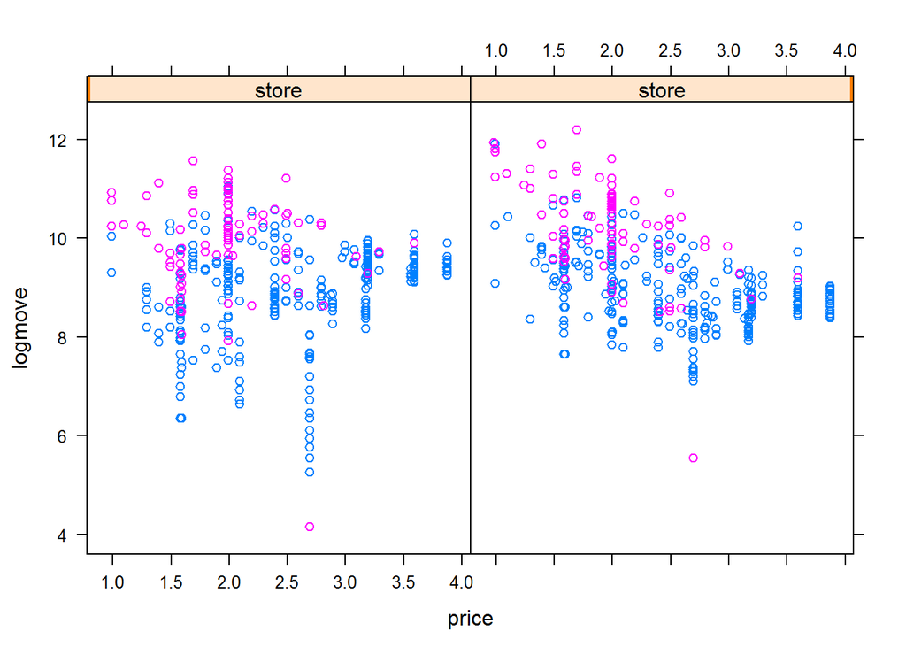

```r
xyplot(logmove~price|store,groups=feat,data=oj3)
```

```r
## store in the wealthiest neighborhood
mhigh=lm(logmove~price,data=oj1)
summary(mhigh)
```

```
##
## Call:
## lm(formula = logmove ~ price, data = oj1)
##
## Residuals:
##     Min      1Q  Median      3Q     Max
## -4.9557 -0.4934  0.1815  0.6557  2.4454
##
## Coefficients:
##             Estimate Std. Error t value Pr(>|t|)
## (Intercept)  9.15394    0.21112  43.359   <2e-16 ***
## price       -0.01461    0.08381  -0.174    0.862
## ---
## Signif. codes:  0 '***' 0.001 '**' 0.01 '*' 0.05 '.' 0.1 ' ' 1
##
## Residual standard error: 1.142 on 349 degrees of freedom
## Multiple R-squared:  8.712e-05,  Adjusted R-squared:  -0.002778
## F-statistic: 0.03041 on 1 and 349 DF,  p-value: 0.8617
```

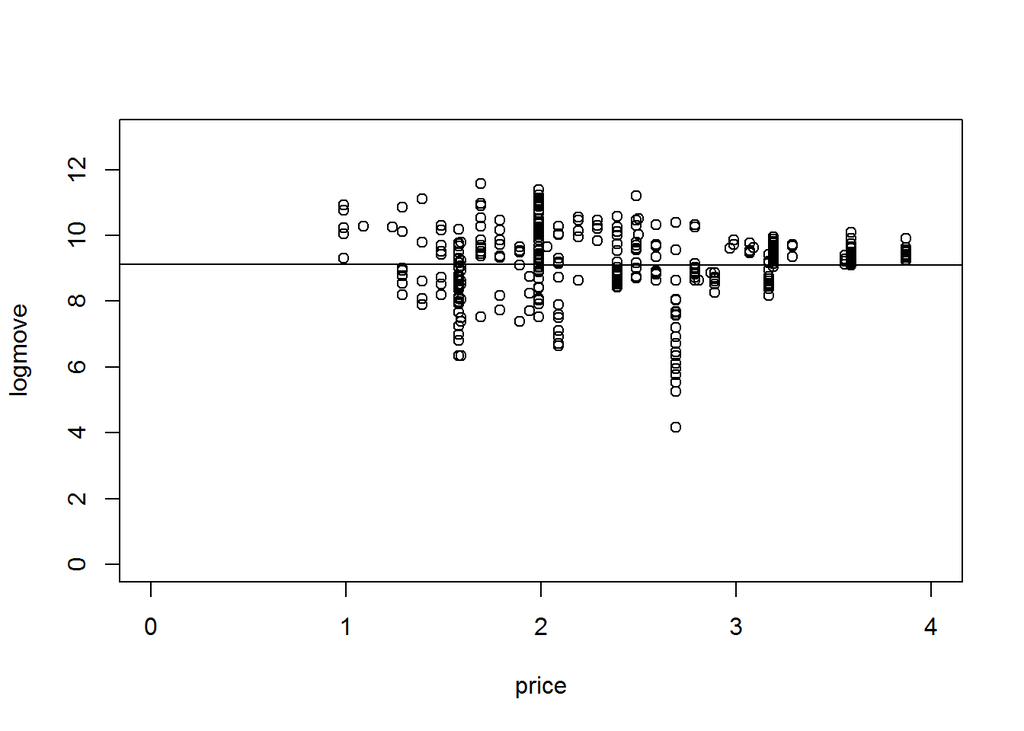

```r
plot(logmove~price,data=oj1,xlim=c(0,4),ylim=c(0,13))
abline(mhigh)
```

```r
## store in the poorest neighborhood
mlow=lm(logmove~price,data=oj2)
summary(mlow)
```

```
##
## Call:
## lm(formula = logmove ~ price, data = oj2)
##
## Residuals:
##     Min      1Q  Median      3Q     Max
## -3.5235 -0.5606  0.0392  0.5090  2.4523
##
## Coefficients:
##             Estimate Std. Error t value Pr(>|t|)
## (Intercept) 10.87695    0.15184   71.63   <2e-16 ***
## price       -0.67222    0.06071  -11.07   <2e-16 ***
## ---
## Signif. codes:  0 '***' 0.001 '**' 0.01 '*' 0.05 '.' 0.1 ' ' 1
##
## Residual standard error: 0.8383 on 352 degrees of freedom
## Multiple R-squared:  0.2584, Adjusted R-squared:  0.2563
## F-statistic: 122.6 on 1 and 352 DF,  p-value: < 2.2e-16
```

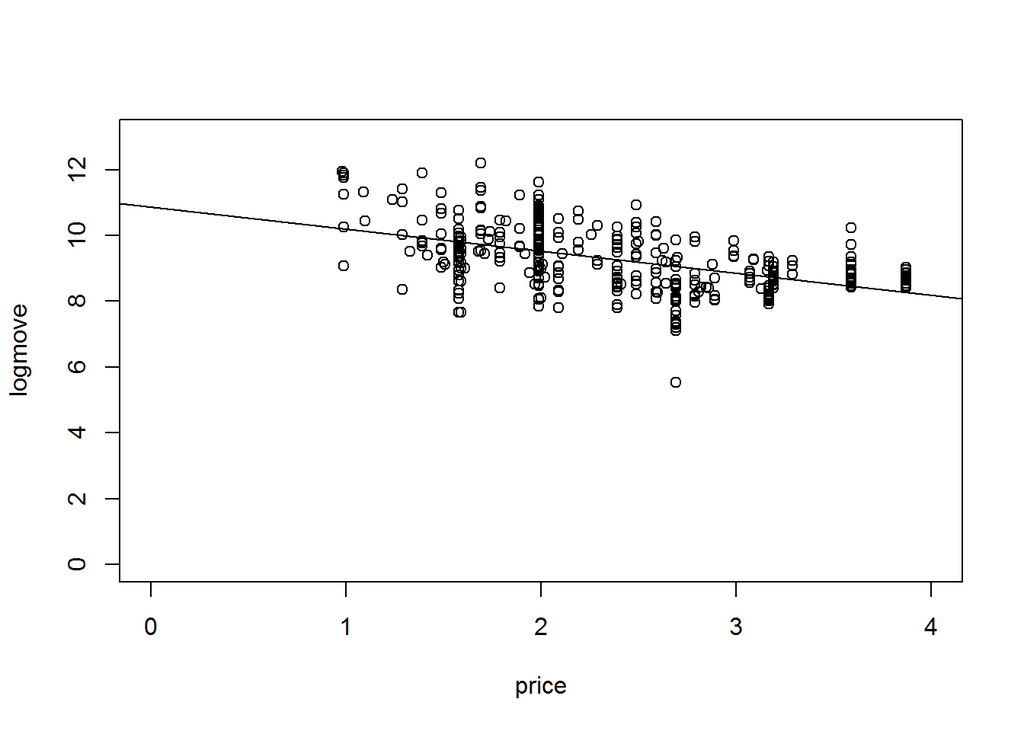

```r
plot(logmove~price,data=oj2,xlim=c(0,4),ylim=c(0,13))
abline(mlow)
```

[linked Reference UCLA.EDU](http://www.ats.ucla.edu/stat/r/pages/looping_strings.htm)